# Covid-19 Cases Analysis

Adib Sobhanian

2024-02-09

## Introduction

This analysis aims to explore the COVID-19 data sourced from the Johns Hopkins University repository. The data includes global and US confirmed cases as well as deaths, which will be analyzed and visualized to gain insights into the pandemic’s progression.

## Retrieving Data from Johns Hopkins University Repository

In this section, we will retrieve the latest COVID-19 data from the Johns Hopkins University repository. The data is divided into four files: global confirmed cases, global deaths, US confirmed cases, and US deaths.

```r
## Get current data in the four files
## They all begin the same way
url_in <- "https://raw.githubusercontent.com/CSSEGISandData/COVID-19/master/csse_covid_19_data/csse_covid_19_time_series/"

file_names <- c("time_series_covid19_confirmed_global.csv",
                "time_series_covid19_deaths_global.csv",
                "time_series_covid19_confirmed_US.csv",
                "time_series_covid19_deaths_US.csv")
urls <- str_c(url_in, file_names)
```

lets read in the data and see what we have.

```r
# Display the URLs
urls
```

```
## [1] "https://raw.githubusercontent.com/CSSEGISandData/COVID-19/master/csse_covid_19_data/csse_covid_19_time_series/time_series_covid19_confirmed_global.csv"
## [2] "https://raw.githubusercontent.com/CSSEGISandData/COVID-19/master/csse_covid_19_data/csse_covid_19_time_series/time_series_covid19_deaths_global.csv"
## [3] "https://raw.githubusercontent.com/CSSEGISandData/COVID-19/master/csse_covid_19_data/csse_covid_19_time_series/time_series_covid19_confirmed_US.csv"
## [4] "https://raw.githubusercontent.com/CSSEGISandData/COVID-19/master/csse_covid_19_data/csse_covid_19_time_series/time_series_covid19_deaths_US.csv"
```

By executing the above code chunk, you will obtain the URLs for the respective data files, which will then be used to import the data in the subsequent code chunks.

```r
# Importing the data files
global_cases <- read_csv(urls[1])
global_deaths <- read_csv(urls[2])
US_cases <- read_csv(urls[3])
US_deaths <- read_csv(urls[4])
```

## Exploring Raw Data

Let’s examine the raw data obtained from the Johns Hopkins University repository to understand its structure and contents.

```r
# Displaying global cases and deaths data
global_cases
```

```
## # A tibble: 289 × 1,147
##    `Province/State`  `Country/Region`   Lat   Long `1/22/20` `1/23/20` `1/24/20`
##    <chr>             <chr>            <dbl>  <dbl>     <dbl>     <dbl>     <dbl>
##  1 <NA>              Afghanistan       33.9  67.7          0         0         0
##  2 <NA>              Albania           41.2  20.2          0         0         0
##  3 <NA>              Algeria           28.0   1.66         0         0         0
##  4 <NA>              Andorra           42.5   1.52         0         0         0
##  5 <NA>              Angola           -11.2  17.9          0         0         0
##  6 <NA>              Antarctica       -71.9  23.3          0         0         0
##  7 <NA>              Antigua and Bar…  17.1 -61.8          0         0         0
##  8 <NA>              Argentina        -38.4 -63.6          0         0         0
##  9 <NA>              Armenia           40.1  45.0          0         0         0
## 10 Australian Capit… Australia        -35.5 149.           0         0         0
## # ℹ 279 more rows
## # ℹ 1,140 more variables: `1/25/20` <dbl>, `1/26/20` <dbl>, `1/27/20` <dbl>,
## #   `1/28/20` <dbl>, `1/29/20` <dbl>, `1/30/20` <dbl>, `1/31/20` <dbl>,
## #   `2/1/20` <dbl>, `2/2/20` <dbl>, `2/3/20` <dbl>, `2/4/20` <dbl>,
## #   `2/5/20` <dbl>, `2/6/20` <dbl>, `2/7/20` <dbl>, `2/8/20` <dbl>,
## #   `2/9/20` <dbl>, `2/10/20` <dbl>, `2/11/20` <dbl>, `2/12/20` <dbl>,
## #   `2/13/20` <dbl>, `2/14/20` <dbl>, `2/15/20` <dbl>, `2/16/20` <dbl>, …
```

```r
global_deaths
```

```
## # A tibble: 289 × 1,147
##    `Province/State`  `Country/Region`   Lat   Long `1/22/20` `1/23/20` `1/24/20`
##    <chr>             <chr>            <dbl>  <dbl>     <dbl>     <dbl>     <dbl>
##  1 <NA>              Afghanistan       33.9  67.7          0         0         0
##  2 <NA>              Albania           41.2  20.2          0         0         0
##  3 <NA>              Algeria           28.0   1.66         0         0         0
##  4 <NA>              Andorra           42.5   1.52         0         0         0
##  5 <NA>              Angola           -11.2  17.9          0         0         0
##  6 <NA>              Antarctica       -71.9  23.3          0         0         0
##  7 <NA>              Antigua and Bar…  17.1 -61.8          0         0         0
##  8 <NA>              Argentina        -38.4 -63.6          0         0         0
##  9 <NA>              Armenia           40.1  45.0          0         0         0
## 10 Australian Capit… Australia        -35.5 149.           0         0         0
## # ℹ 279 more rows
## # ℹ 1,140 more variables: `1/25/20` <dbl>, `1/26/20` <dbl>, `1/27/20` <dbl>,
## #   `1/28/20` <dbl>, `1/29/20` <dbl>, `1/30/20` <dbl>, `1/31/20` <dbl>,
## #   `2/1/20` <dbl>, `2/2/20` <dbl>, `2/3/20` <dbl>, `2/4/20` <dbl>,
## #   `2/5/20` <dbl>, `2/6/20` <dbl>, `2/7/20` <dbl>, `2/8/20` <dbl>,
## #   `2/9/20` <dbl>, `2/10/20` <dbl>, `2/11/20` <dbl>, `2/12/20` <dbl>,
## #   `2/13/20` <dbl>, `2/14/20` <dbl>, `2/15/20` <dbl>, `2/16/20` <dbl>, …
```

After reviewing the raw data for global cases and deaths, we will tidy up these datasets by restructuring them and removing unnecessary columns.

```r
# Tidying global cases data
global_cases <- global_cases %>%
  pivot_longer(cols = -c(`Province/State`,`Country/Region`,Lat, Long),
      names_to = "date",
      values_to = "cases") %>%
  select (-c(Lat, Long))

# Tidying global deaths data
global_deaths <- global_deaths %>%
  pivot_longer(cols = -c(`Province/State`,`Country/Region`,Lat, Long),
      names_to = "date",
      values_to = "deaths") %>%
  select (-c(Lat, Long))

# Combining global cases and deaths data
global <- global_cases %>%
  full_join(global_deaths) %>%
  rename(`Country/Region` = `Country/Region`,
         `Province/State`= `Province/State`) %>%
  mutate(date = mdy(date))
# Displaying the tidied global data
global
```

```
## # A tibble: 330,327 × 5
##    `Province/State` `Country/Region` date       cases deaths
##    <chr>            <chr>            <date>     <dbl>  <dbl>
##  1 <NA>             Afghanistan      2020-01-22     0      0
##  2 <NA>             Afghanistan      2020-01-23     0      0
##  3 <NA>             Afghanistan      2020-01-24     0      0
##  4 <NA>             Afghanistan      2020-01-25     0      0
##  5 <NA>             Afghanistan      2020-01-26     0      0
##  6 <NA>             Afghanistan      2020-01-27     0      0
##  7 <NA>             Afghanistan      2020-01-28     0      0
##  8 <NA>             Afghanistan      2020-01-29     0      0
##  9 <NA>             Afghanistan      2020-01-30     0      0
## 10 <NA>             Afghanistan      2020-01-31     0      0
## # ℹ 330,317 more rows
```

```r
summary(global)
```

```
##  Province/State     Country/Region          date                cases
##  Length:330327      Length:330327      Min.   :2020-01-22   Min.   :        0
##  Class :character   Class :character   1st Qu.:2020-11-02   1st Qu.:      680
##  Mode  :character   Mode  :character   Median :2021-08-15   Median :    14429
##                                        Mean   :2021-08-15   Mean   :   959384
##                                        3rd Qu.:2022-05-28   3rd Qu.:   228517
##                                        Max.   :2023-03-09   Max.   :103802702
##      deaths
##  Min.   :      0
##  1st Qu.:      3
##  Median :    150
##  Mean   :  13380
##  3rd Qu.:   3032
##  Max.   :1123836
```

If you pay attention in summary you will notice that there have been dates that minimum number of positive cases were zero, you can use the following command to filter out only positive cases and check summary(global) again

```r
global <- global %>% filter(cases > 0)
```

To make sure the maximum number of positive cases in one day is not a typo you can use following filter command with an arbitrary number to check how many days there were positive cases more than the set value.

```r
global %>% filter(cases > 100000000)
```

```
## # A tibble: 80 × 5
##    `Province/State` `Country/Region` date           cases  deaths
##    <chr>            <chr>            <date>         <dbl>   <dbl>
##  1 <NA>             US               2022-12-20 100050937 1088341
##  2 <NA>             US               2022-12-21 100233060 1089383
##  3 <NA>             US               2022-12-22 100329204 1089979
##  4 <NA>             US               2022-12-23 100368433 1090186
##  5 <NA>             US               2022-12-24 100374955 1090208
##  6 <NA>             US               2022-12-25 100378169 1090223
##  7 <NA>             US               2022-12-26 100390601 1090252
##  8 <NA>             US               2022-12-27 100501536 1090608
##  9 <NA>             US               2022-12-28 100614880 1091598
## 10 <NA>             US               2022-12-29 100718983 1092522
## # ℹ 70 more rows
```

## Exploring and Tidying US Data

Next, we’ll focus on exploring and tidying the US-specific data for both cases and deaths.

```r
US_cases
```

```
## # A tibble: 3,342 × 1,154
##         UID iso2  iso3  code3  FIPS Admin2   Province_State Country_Region   Lat
##       <dbl> <chr> <chr> <dbl> <dbl> <chr>    <chr>          <chr>          <dbl>
##  1 84001001 US    USA     840  1001 Autauga  Alabama        US              32.5
##  2 84001003 US    USA     840  1003 Baldwin  Alabama        US              30.7
##  3 84001005 US    USA     840  1005 Barbour  Alabama        US              31.9
##  4 84001007 US    USA     840  1007 Bibb     Alabama        US              33.0
##  5 84001009 US    USA     840  1009 Blount   Alabama        US              34.0
##  6 84001011 US    USA     840  1011 Bullock  Alabama        US              32.1
##  7 84001013 US    USA     840  1013 Butler   Alabama        US              31.8
##  8 84001015 US    USA     840  1015 Calhoun  Alabama        US              33.8
##  9 84001017 US    USA     840  1017 Chambers Alabama        US              32.9
## 10 84001019 US    USA     840  1019 Cherokee Alabama        US              34.2
## # ℹ 3,332 more rows
## # ℹ 1,145 more variables: Long_ <dbl>, Combined_Key <chr>, `1/22/20` <dbl>,
## #   `1/23/20` <dbl>, `1/24/20` <dbl>, `1/25/20` <dbl>, `1/26/20` <dbl>,
## #   `1/27/20` <dbl>, `1/28/20` <dbl>, `1/29/20` <dbl>, `1/30/20` <dbl>,
## #   `1/31/20` <dbl>, `2/1/20` <dbl>, `2/2/20` <dbl>, `2/3/20` <dbl>,
## #   `2/4/20` <dbl>, `2/5/20` <dbl>, `2/6/20` <dbl>, `2/7/20` <dbl>,
## #   `2/8/20` <dbl>, `2/9/20` <dbl>, `2/10/20` <dbl>, `2/11/20` <dbl>, …
```

We can start filtering things that we don’t need out. convert the date data into Date object instead of Char

```r
# Tidying US cases data
US_cases <- US_cases %>%
  pivot_longer(cols = -(UID:Combined_Key),
               names_to = "date",
               values_to = "cases") %>%
  select(Admin2:cases) %>%
  mutate(date = mdy(date)) %>%
  select(-c(Lat, Long_))

# Displaying tidied US cases data
US_cases
```

```
## # A tibble: 3,819,906 × 6
##    Admin2  Province_State Country_Region Combined_Key         date       cases
##    <chr>   <chr>          <chr>          <chr>                <date>     <dbl>
##  1 Autauga Alabama        US             Autauga, Alabama, US 2020-01-22     0
##  2 Autauga Alabama        US             Autauga, Alabama, US 2020-01-23     0
##  3 Autauga Alabama        US             Autauga, Alabama, US 2020-01-24     0
##  4 Autauga Alabama        US             Autauga, Alabama, US 2020-01-25     0
##  5 Autauga Alabama        US             Autauga, Alabama, US 2020-01-26     0
##  6 Autauga Alabama        US             Autauga, Alabama, US 2020-01-27     0
##  7 Autauga Alabama        US             Autauga, Alabama, US 2020-01-28     0
##  8 Autauga Alabama        US             Autauga, Alabama, US 2020-01-29     0
##  9 Autauga Alabama        US             Autauga, Alabama, US 2020-01-30     0
## 10 Autauga Alabama        US             Autauga, Alabama, US 2020-01-31     0
## # ℹ 3,819,896 more rows
```

Similarly, we’ll tidy the US deaths data, ensuring consistency in format and content.

```r
# Tidying US deaths data
US_deaths
```

```
## # A tibble: 3,342 × 1,155
##         UID iso2  iso3  code3  FIPS Admin2   Province_State Country_Region   Lat
##       <dbl> <chr> <chr> <dbl> <dbl> <chr>    <chr>          <chr>          <dbl>
##  1 84001001 US    USA     840  1001 Autauga  Alabama        US              32.5
##  2 84001003 US    USA     840  1003 Baldwin  Alabama        US              30.7
##  3 84001005 US    USA     840  1005 Barbour  Alabama        US              31.9
##  4 84001007 US    USA     840  1007 Bibb     Alabama        US              33.0
##  5 84001009 US    USA     840  1009 Blount   Alabama        US              34.0
##  6 84001011 US    USA     840  1011 Bullock  Alabama        US              32.1
##  7 84001013 US    USA     840  1013 Butler   Alabama        US              31.8
##  8 84001015 US    USA     840  1015 Calhoun  Alabama        US              33.8
##  9 84001017 US    USA     840  1017 Chambers Alabama        US              32.9
## 10 84001019 US    USA     840  1019 Cherokee Alabama        US              34.2
## # ℹ 3,332 more rows
## # ℹ 1,146 more variables: Long_ <dbl>, Combined_Key <chr>, Population <dbl>,
## #   `1/22/20` <dbl>, `1/23/20` <dbl>, `1/24/20` <dbl>, `1/25/20` <dbl>,
## #   `1/26/20` <dbl>, `1/27/20` <dbl>, `1/28/20` <dbl>, `1/29/20` <dbl>,
## #   `1/30/20` <dbl>, `1/31/20` <dbl>, `2/1/20` <dbl>, `2/2/20` <dbl>,
## #   `2/3/20` <dbl>, `2/4/20` <dbl>, `2/5/20` <dbl>, `2/6/20` <dbl>,
## #   `2/7/20` <dbl>, `2/8/20` <dbl>, `2/9/20` <dbl>, `2/10/20` <dbl>, …
```

```r
US_deaths <- US_deaths %>%
  pivot_longer(cols = -(UID:Population),
               names_to = "date",
               values_to = "deaths") %>%
  select(Admin2:deaths) %>%
  mutate(date = mdy(date)) %>%
  select(-c(Lat, Long_))

# Displaying tidied US deaths data
US_deaths
```

```
## # A tibble: 3,819,906 × 7
##    Admin2  Province_State Country_Region Combined_Key      Population date
##    <chr>   <chr>          <chr>          <chr>                  <dbl> <date>
##  1 Autauga Alabama        US             Autauga, Alabama…      55869 2020-01-22
##  2 Autauga Alabama        US             Autauga, Alabama…      55869 2020-01-23
##  3 Autauga Alabama        US             Autauga, Alabama…      55869 2020-01-24
##  4 Autauga Alabama        US             Autauga, Alabama…      55869 2020-01-25
##  5 Autauga Alabama        US             Autauga, Alabama…      55869 2020-01-26
##  6 Autauga Alabama        US             Autauga, Alabama…      55869 2020-01-27
##  7 Autauga Alabama        US             Autauga, Alabama…      55869 2020-01-28
##  8 Autauga Alabama        US             Autauga, Alabama…      55869 2020-01-29
##  9 Autauga Alabama        US             Autauga, Alabama…      55869 2020-01-30
## 10 Autauga Alabama        US             Autauga, Alabama…      55869 2020-01-31
## # ℹ 3,819,896 more rows
## # ℹ 1 more variable: deaths <dbl>
```

Now, let’s merge the tidied US cases and deaths data into a single dataset for further analysis.

```r
US <- US_cases %>%
  full_join(US_deaths)
```

[output not shown]

### Adding Population Data to Global Dataset

To perform comparative analysis across countries, we need to add population data to our global dataset. We’ll import population data from the same source as our COVID-19 data and merge it with our global dataset.

```r
global <- global %>%
  unite("Combined_Key",
  c('Province/State', 'Country/Region'),
  sep = ", ",
  na.rm = TRUE,
  remove = FALSE)
```

Now we can import the population data that we found on the website from the same source to our global data.

```r
# Define the URL for population data
uid_lookup_url <- "https://raw.githubusercontent.com/CSSEGISandData/COVID-19/master/csse_covid_19_data/UID_ISO_FIPS_LookUp_Table.csv"

# Read the population data from the URL
uid <- read.csv(uid_lookup_url) %>%
  select(-c(Lat, Long_, Combined_Key , code3, iso2, iso3, Admin2))

# Rename columns in global dataset for consistency
global <- global %>%
  rename(Province_State = `Province/State`, Country_Region = `Country/Region`)

# Merge population data with global dataset
global <- global %>%
  left_join(uid, by = c("Province_State", "Country_Region")) %>%
  select(-c(UID, FIPS)) %>%
  select(Province_State, Country_Region, date, cases, deaths, Population, Combined_Key)

# Displaying the updated global dataset
global
```

```
## # A tibble: 306,827 × 7
##    Province_State Country_Region date       cases deaths Population Combined_Key
##    <chr>          <chr>          <date>     <dbl>  <dbl>      <int> <chr>
##  1 <NA>           Afghanistan    2020-02-24     5      0         NA Afghanistan
##  2 <NA>           Afghanistan    2020-02-25     5      0         NA Afghanistan
##  3 <NA>           Afghanistan    2020-02-26     5      0         NA Afghanistan
##  4 <NA>           Afghanistan    2020-02-27     5      0         NA Afghanistan
##  5 <NA>           Afghanistan    2020-02-28     5      0         NA Afghanistan
##  6 <NA>           Afghanistan    2020-02-29     5      0         NA Afghanistan
##  7 <NA>           Afghanistan    2020-03-01     5      0         NA Afghanistan
##  8 <NA>           Afghanistan    2020-03-02     5      0         NA Afghanistan
##  9 <NA>           Afghanistan    2020-03-03     5      0         NA Afghanistan
## 10 <NA>           Afghanistan    2020-03-04     5      0         NA Afghanistan
## # ℹ 306,817 more rows
```

## Analyzing US Data

Let’s start by analyzing the US data, examining both overall trends and state-level details.

```r
# Aggregate US data by state and date
US_by_state <- US %>%
    group_by(Province_State, Country_Region, date) %>%
    summarize(cases= sum(cases), deaths= sum(deaths), Population= sum(Population)) %>%
    mutate(deaths_per_mill= deaths* 1000000 / Population) %>%
    select(Province_State, Country_Region, date, cases, deaths, deaths_per_mill, Population) %>%
    ungroup()
# Displaying the aggregated US data
US_by_state
```

```
## # A tibble: 66,294 × 7
##    Province_State Country_Region date       cases deaths deaths_per_mill
##    <chr>          <chr>          <date>     <dbl>  <dbl>           <dbl>
##  1 Alabama        US             2020-01-22     0      0               0
##  2 Alabama        US             2020-01-23     0      0               0
##  3 Alabama        US             2020-01-24     0      0               0
##  4 Alabama        US             2020-01-25     0      0               0
##  5 Alabama        US             2020-01-26     0      0               0
##  6 Alabama        US             2020-01-27     0      0               0
##  7 Alabama        US             2020-01-28     0      0               0
##  8 Alabama        US             2020-01-29     0      0               0
##  9 Alabama        US             2020-01-30     0      0               0
## 10 Alabama        US             2020-01-31     0      0               0
## # ℹ 66,284 more rows
## # ℹ 1 more variable: Population <dbl>
```

Next, let’s analyze the total COVID-19 cases and deaths for the entire US.

```r
# Aggregate total US data
US_totals <- US_by_state %>%
    group_by(Country_Region, date) %>%
    summarize(cases= sum(cases), deaths= sum(deaths), Population= sum(Population)) %>%
    mutate(deaths_per_mill= deaths * 1000000 / Population) %>%
    select(Country_Region, date, cases, deaths, deaths_per_mill, Population) %>%
    ungroup()
# Displaying the total US data
US_totals
```

```
## # A tibble: 1,143 × 6
##    Country_Region date       cases deaths deaths_per_mill Population
##    <chr>          <date>     <dbl>  <dbl>           <dbl>      <dbl>
##  1 US             2020-01-22     1      1         0.00300  332875137
##  2 US             2020-01-23     1      1         0.00300  332875137
##  3 US             2020-01-24     2      1         0.00300  332875137
##  4 US             2020-01-25     2      1         0.00300  332875137
##  5 US             2020-01-26     5      1         0.00300  332875137
##  6 US             2020-01-27     5      1         0.00300  332875137
##  7 US             2020-01-28     5      1         0.00300  332875137
##  8 US             2020-01-29     6      1         0.00300  332875137
##  9 US             2020-01-30     6      1         0.00300  332875137
## 10 US             2020-01-31     8      1         0.00300  332875137
## # ℹ 1,133 more rows
```

We can also see the end of the table by this command

```r
tail(US_totals)
```

```
## # A tibble: 6 × 6
##   Country_Region date           cases  deaths deaths_per_mill Population
##   <chr>          <date>         <dbl>   <dbl>           <dbl>      <dbl>
## 1 US             2023-03-04 103650837 1122172           3371.  332875137
## 2 US             2023-03-05 103646975 1122134           3371.  332875137
## 3 US             2023-03-06 103655539 1122181           3371.  332875137
## 4 US             2023-03-07 103690910 1122516           3372.  332875137
## 5 US             2023-03-08 103755771 1123246           3374.  332875137
## 6 US             2023-03-09 103802702 1123836           3376.  332875137
```

## Visuals

Now We can also visualize the total number of cases and deaths in the US over time.

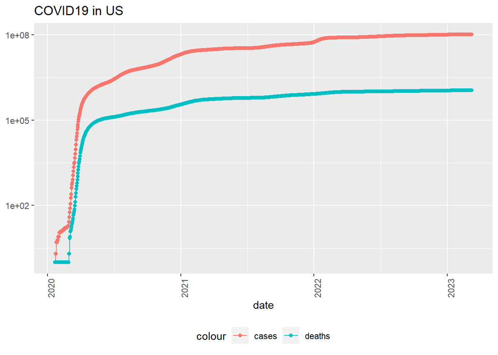

```r
# Visualizing total US cases and deaths over time
US_totals %>%
    filter(cases > 0) %>%
    ggplot(aes(x = date, y= cases)) +
    geom_line(aes(color= "cases")) +
    geom_point(aes(color= "cases")) +
    geom_line(aes(y= deaths, color= "deaths")) +
    geom_point(aes(y= deaths, color= "deaths")) +
    scale_y_log10() +
    theme(legend.position = "bottom", axis.text.x = element_text(angle = 90)) +
    labs(title = "COVID19 in US", y= NULL)
```

We’ll continue the analysis by examining specific states, such as New York, and exploring trends at the state level.

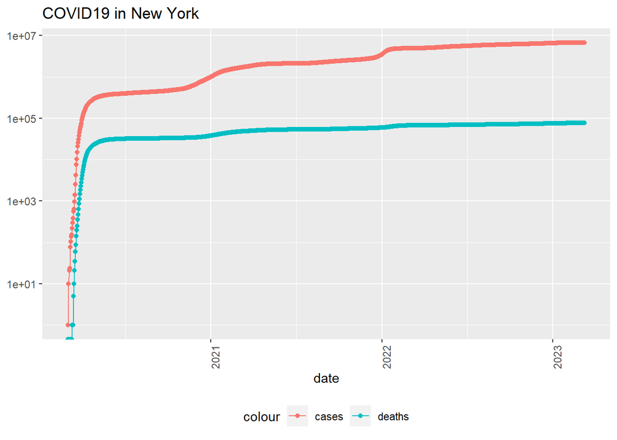

```r
# Visualizing COVID-19 trends in New York
state <- "New York"
US_by_state %>%
    filter(Province_State == state) %>%
    filter(cases > 0) %>%
    ggplot(aes(x = date, y= cases)) +
    geom_line(aes(color= "cases")) +
    geom_point(aes(color= "cases")) +
    geom_line(aes(y= deaths, color= "deaths")) +
    geom_point(aes(y= deaths, color= "deaths")) +
    scale_y_log10() +
    theme(legend.position = "bottom", axis.text.x = element_text(angle = 90)) +
    labs(title = str_c("COVID19 in ", state), y= NULL)
```

Now that we have done our basic visualization before we do any modeling We notice that the number of cases and deaths are flattening out so we can do an analysis on that by adding new lag variables to our data

```r
max(US_totals$date)
```

```
## [1] "2023-03-09"
```

```r
max(US_totals$deaths)
```

```
## [1] 1123836
```

```r
US_by_state <- US_by_state %>%
  mutate(new_cases = cases - lag(cases),
         new_deaths= deaths - lag(deaths))
US_totals <- US_totals %>%
  mutate(new_cases= cases - lag(cases),
         new_deaths= deaths- lag(deaths))

tail(US_totals)
```

```
## # A tibble: 6 × 8
##   Country_Region date          cases deaths deaths_per_mill Population new_cases
##   <chr>          <date>        <dbl>  <dbl>           <dbl>      <dbl>     <dbl>
## 1 US             2023-03-04   1.04e8 1.12e6           3371.  332875137      2147
## 2 US             2023-03-05   1.04e8 1.12e6           3371.  332875137     -3862
## 3 US             2023-03-06   1.04e8 1.12e6           3371.  332875137      8564
## 4 US             2023-03-07   1.04e8 1.12e6           3372.  332875137     35371
## 5 US             2023-03-08   1.04e8 1.12e6           3374.  332875137     64861
## 6 US             2023-03-09   1.04e8 1.12e6           3376.  332875137     46931
## # ℹ 1 more variable: new_deaths <dbl>
```

```r
tail(US_totals %>% select(new_cases, new_deaths, everything()))
```

```
## # A tibble: 6 × 8
##   new_cases new_deaths Country_Region date          cases deaths deaths_per_mill
##       <dbl>      <dbl> <chr>          <date>        <dbl>  <dbl>           <dbl>
## 1      2147          7 US             2023-03-04   1.04e8 1.12e6           3371.
## 2     -3862        -38 US             2023-03-05   1.04e8 1.12e6           3371.
## 3      8564         47 US             2023-03-06   1.04e8 1.12e6           3371.
## 4     35371        335 US             2023-03-07   1.04e8 1.12e6           3372.
## 5     64861        730 US             2023-03-08   1.04e8 1.12e6           3374.
## 6     46931        590 US             2023-03-09   1.04e8 1.12e6           3376.
## # ℹ 1 more variable: Population <dbl>
```

Now that we have added the new variables lets look at the new visuals to see what that does

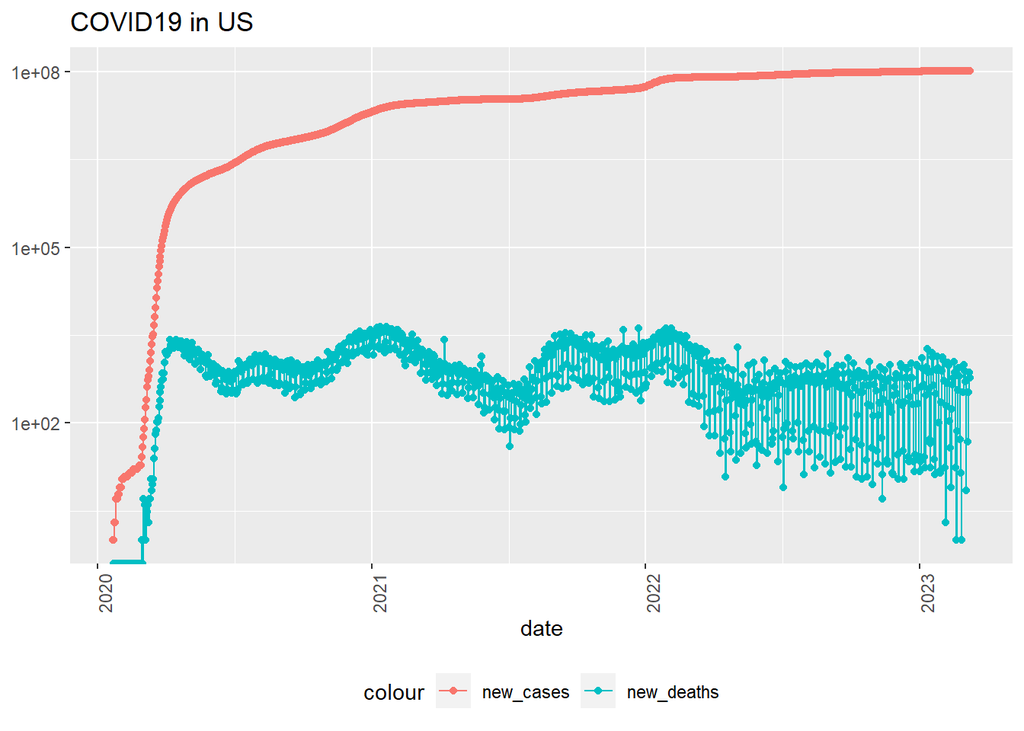

```r
US_totals %>%
    ggplot(aes(x = date, y= cases)) +
    geom_line(aes(color= "new_cases")) +
    geom_point(aes(color= "new_cases")) +
    geom_line(aes(y= new_deaths, color= "new_deaths")) +
    geom_point(aes(y= new_deaths, color= "new_deaths")) +
    scale_y_log10() +
    theme(legend.position = "bottom", axis.text.x = element_text(angle = 90)) +
    labs(title = "COVID19 in US", y= NULL)
```

We could do this for any state or country as well to do a comparassion for now lets look at New York city again to compare.

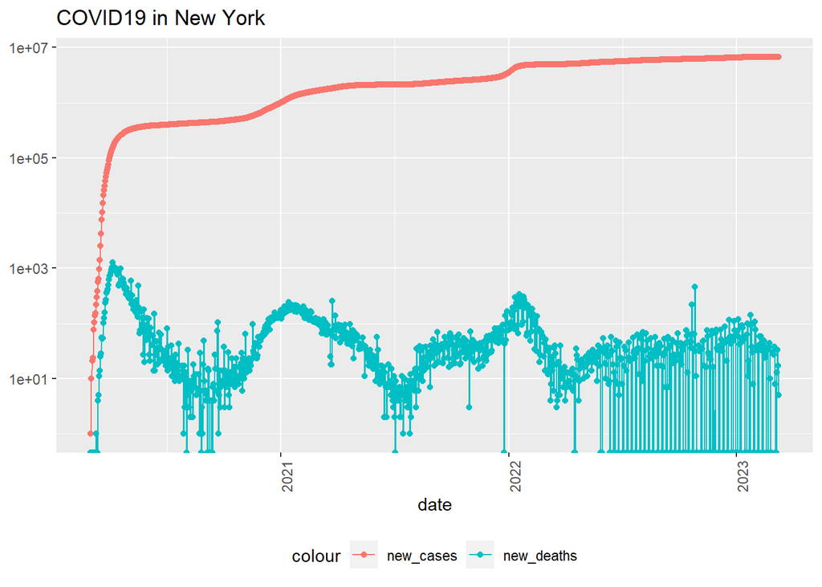

```r
state <- "New York"
US_by_state %>%
    filter(Province_State == state) %>%
    filter(cases > 0) %>%
    ggplot(aes(x = date, y= cases)) +
    geom_line(aes(color= "new_cases")) +
    geom_point(aes(color= "new_cases")) +
    geom_line(aes(y= new_deaths, color= "new_deaths")) +
    geom_point(aes(y= new_deaths, color= "new_deaths")) +
    scale_y_log10() +
    theme(legend.position = "bottom", axis.text.x = element_text(angle = 90)) +
    labs(title = str_c("COVID19 in ", state), y= NULL)
```

We’ll also analyze the top states with the smallest and largest deaths per thousand, providing insights into regional disparities.

```r
# Analyzing states with smallest and largest deaths per thousand
US_state_totals <- US_by_state %>%
  group_by(Province_State) %>%
  summarize(deaths= max(deaths), cases= max(cases), population= max(Population),
            cases_per_thou= 1000* cases / population,
            deaths_per_thou= 1000* deaths / population) %>%
  filter(cases > 0, population > 0)

# Displaying states with smallest and largest deaths per thousand
US_state_totals
```

```
## # A tibble: 56 × 6
##    Province_State       deaths   cases population cases_per_thou deaths_per_thou
##    <chr>                 <dbl>   <dbl>      <dbl>          <dbl>           <dbl>
##  1 Alabama               21032  1.64e6    4903185           335.           4.29
##  2 Alaska                 1486  3.08e5     740995           415.           2.01
##  3 American Samoa           34  8.32e3      55641           150.           0.611
##  4 Arizona               33102  2.44e6    7278717           336.           4.55
##  5 Arkansas              13020  1.01e6    3017804           334.           4.31
##  6 California           101159  1.21e7   39512223           307.           2.56
##  7 Colorado              14181  1.76e6    5758736           306.           2.46
##  8 Connecticut           12220  9.77e5    3565287           274.           3.43
##  9 Delaware               3324  3.31e5     973764           340.           3.41
## 10 District of Columbia   1432  1.78e5     705749           252.           2.03
## # ℹ 46 more rows
```

We can find the top 10 states with smallest death/thousand like this

```r
US_state_totals %>%
  slice_min(deaths_per_thou, n = 10) %>%
select(deaths_per_thou, cases_per_thou, everything())
```

```
## # A tibble: 10 × 6
##    deaths_per_thou cases_per_thou Province_State        deaths  cases population
##              <dbl>          <dbl> <chr>                  <dbl>  <dbl>      <dbl>
##  1           0.611           150. American Samoa            34 8.32e3      55641
##  2           0.744           248. Northern Mariana Isl…     41 1.37e4      55144
##  3           1.21            231. Virgin Islands           130 2.48e4     107268
##  4           1.30            269. Hawaii                  1841 3.81e5    1415872
##  5           1.49            245. Vermont                  929 1.53e5     623989
##  6           1.55            293. Puerto Rico             5823 1.10e6    3754939
##  7           1.65            340. Utah                    5298 1.09e6    3205958
##  8           2.01            415. Alaska                  1486 3.08e5     740995
##  9           2.03            252. District of Columbia    1432 1.78e5     705749
## 10           2.06            253. Washington             15683 1.93e6    7614893
```

```r
US_state_totals %>%
  slice_max(deaths_per_thou, n = 20) %>%
  select(deaths_per_thou, cases_per_thou, everything())
```

```
## # A tibble: 20 × 6
##    deaths_per_thou cases_per_thou Province_State deaths   cases population
##              <dbl>          <dbl> <chr>           <dbl>   <dbl>      <dbl>
##  1            4.55           336. Arizona         33102 2443514    7278717
##  2            4.54           326. Oklahoma        17972 1290929    3956971
##  3            4.49           333. Mississippi     13370  990756    2976149
##  4            4.44           359. West Virginia    7960  642760    1792147
##  5            4.32           320. New Mexico       9061  670929    2096829
##  6            4.31           334. Arkansas        13020 1006883    3017804
##  7            4.29           335. Alabama         21032 1644533    4903185
##  8            4.28           368. Tennessee       29263 2515130    6829174
##  9            4.23           307. Michigan        42205 3064125    9986857
## 10            4.06           385. Kentucky        18130 1718471    4467673
## 11            4.05           343. New Jersey      36015 3048984    8882190
## 12            4.04           353. Florida         86850 7574590   21477737
## 13            4.04           339. Louisiana       18766 1573810    4648794
## 14            4.00           289. Georgia         42489 3068208   10617423
## 15            3.97           349. New York        77157 6794738   19453561
## 16            3.94           276. Pennsylvania    50398 3527854   12801989
## 17            3.88           305. Indiana         26115 2051104    6732219
## 18            3.87           289. Nevada          11922  890122    3080156
## 19            3.81           357. South Carolina  19600 1836568    5148714
## 20            3.65           435. Rhode Island     3870  460697    1059361
```

### Modeling the data

So this is part of the iterative process that you will go through as you analyze your data. You may need to introduce more variables here to build your model, depending on what you have found out so far. What do you want to consider? Do you want to consider population density, extent of the lockdown, political affiliation, climate of the area? There’s all sorts of things that you may want to introduce and add as variables into your model.

Now, for purposes of our demonstration, we are going to choose a very simple thing that we don’t have to add any variables to our data for. So I’m just going to look at, right now, at a linear model. So a linear model means the variable that I want to look at is predicted by other variables in a linear fashion. So for instance, here I’m going to look at the deaths per 1,000 being a function of the cases per 1,000 and see what I get out of that model.

```r
mod <- lm(deaths_per_thou ~ cases_per_thou, data = US_state_totals)
summary(mod)
```

```
##
## Call:
## lm(formula = deaths_per_thou ~ cases_per_thou, data = US_state_totals)
##
## Residuals:
##     Min      1Q  Median      3Q     Max
## -2.3352 -0.5978  0.1491  0.6535  1.2086
##
## Coefficients:
##                Estimate Std. Error t value Pr(>|t|)
## (Intercept)    -0.36167    0.72480  -0.499     0.62
## cases_per_thou  0.01133    0.00232   4.881 9.76e-06 ***
## ---
## Signif. codes:  0 '***' 0.001 '**' 0.01 '*' 0.05 '.' 0.1 ' ' 1
##
## Residual standard error: 0.8615 on 54 degrees of freedom
## Multiple R-squared:  0.3061, Adjusted R-squared:  0.2933
## F-statistic: 23.82 on 1 and 54 DF,  p-value: 9.763e-06
```

We can see the coefficients and p-values and so forth. So we can see that basically what this is telling us is that this model would say our deaths per 1,000 are -0.36167 plus 0.01133 times the number of cases per 1,000

If we wanna see how many cases per thousand are smallest and how many are the largest

```r
US_state_totals %>% slice_min(cases_per_thou)
```

```
## # A tibble: 1 × 6
##   Province_State deaths cases population cases_per_thou deaths_per_thou
##   <chr>           <dbl> <dbl>      <dbl>          <dbl>           <dbl>
## 1 American Samoa     34  8320      55641           150.           0.611
```

```r
US_state_totals %>% slice_max(cases_per_thou)
```

```
## # A tibble: 1 × 6
##   Province_State deaths  cases population cases_per_thou deaths_per_thou
##   <chr>           <dbl>  <dbl>      <dbl>          <dbl>           <dbl>
## 1 Rhode Island     3870 460697    1059361           435.            3.65
```

Now let create a data set with prediction added in there

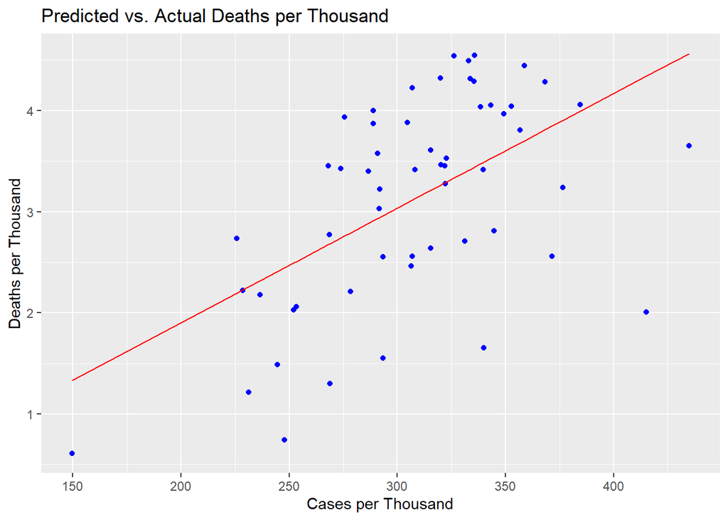

```r
# Create a grid of cases per thousand for prediction
x_grid <- seq(1, 435)

# Create a new dataframe with the grid and use the model to predict deaths_per_thou
new_df <- tibble(cases_per_thou = x_grid)

# Predict deaths_per_thou using the model
new_df <- new_df %>%
  mutate(pred = predict(mod, newdata = new_df))

# Combine the predicted values with the US_state_totals dataframe
US_tot_w_pred <- US_state_totals %>%
  mutate(pred = predict(mod))

# Plotting
US_tot_w_pred %>%
  ggplot() +
  geom_point(aes(x = cases_per_thou, y = deaths_per_thou), color = "blue") +
  geom_line(aes(x = cases_per_thou, y = pred), color = "red") +
  labs(title = "Predicted vs. Actual Deaths per Thousand",
       x = "Cases per Thousand",
       y = "Deaths per Thousand")
```

## Analysis

### US-Specific Insights:

State-Level Analysis: Examination of COVID-19 data at the state level in the US highlighted regional disparities in the spread and impact of the virus. States like New York experienced significant outbreaks early in the pandemic, while others faced less severe consequences.

### Key Findings:

Regional Disparities: The analysis revealed significant regional disparities in COVID-19 outcomes, with some states experiencing higher death rates per thousand population compared to others.

## Bias

### Sources of Bias:

Selection Bias: The data may not be representative of the entire population, leading to skewed results. For example, if testing is more readily available in certain regions or demographic groups, it could lead to underrepresentation or overrepresentation of cases and deaths. Reporting Bias: Inaccurate or incomplete reporting of COVID-19 cases and deaths could introduce bias into the analysis. Variations in reporting standards between regions or countries may affect the reliability and comparability of the data. Confounding Variables: Failure to account for confounding variables, such as testing capacity, healthcare infrastructure, and public health interventions, could confound the relationship between COVID-19 cases, deaths, and other factors.

### Prevention Strategies:

Random Sampling: Implement random sampling techniques to ensure that the data collected is representative of the entire population. This can help mitigate selection bias by reducing the likelihood of overrepresentation or underrepresentation of certain groups. Standardized Reporting: Establish standardized reporting protocols to ensure consistency and accuracy in COVID-19 data collection and reporting. Collaboration between local, national, and international health agencies can help harmonize reporting standards and improve data quality. Control for Confounding Variables: When conducting data analysis, carefully control for confounding variables by including them in the analysis or conducting stratified analyses. This can help identify and account for potential biases introduced by factors such as testing capacity, healthcare access, and public health interventions. By implementing these prevention strategies, future data analyses can minimize bias and enhance the reliability and validity of findings, ultimately improving our understanding of the COVID-19 pandemic and guiding effective public health responses.

## Future Directions:

Further Research: Future research could explore additional variables, such as vaccination rates, healthcare infrastructure, and socio-economic factors, to better understand the determinants of COVID-19 outcomes.

Policy Implications: Insights gained from the analysis can inform policy decisions aimed at controlling the spread of the virus and minimizing its impact on vulnerable populations.

Continued Monitoring: Continued monitoring of COVID-19 data is essential for detecting emerging trends, identifying hotspots, and guiding targeted interventions to prevent further transmission of the virus.

By leveraging data-driven insights and adopting evidence-based strategies, we can work towards effectively managing the COVID-19 pandemic and safeguarding public health globally.